# Udemy Course Analysis

Victor Nyakako

2022-12-24

### **Introduction**

Udemy is an online learning platform that offers broad range of courses. It is one of the go to platforms among learners seeking to upskill and broaden their horizons.

In this analysis, a dataset containing udemy courses up to 2017 is used. The datasets only focus on business, music, design, and web development courses.

## **Loading the Packages**

The packages used are:

- tidyverse
- janitor
- lubridate
- skimr

## **Loading the Dataset**

```r
web_courses<- read_csv("Web development Courses.csv")
music_courses<- read_csv("Music Courses.csv")
business_courses<- read_csv("Business Courses.csv")
design_courses <- read_csv("Design Courses.csv")
```

## **Merging the Data**

Let’s combine the datasets into a single dataset named “udemy_courses”

```r
udemy_courses <- rbind(business_courses, music_courses, web_courses, design_courses)
```

## **Exploratory Data Analysis**

Let us explore the data, and get to find its structure.

```r
skim(udemy_courses)
```

Data summary

| Name | udemy_courses |
| --- | --- |
| Number of rows | 3681 |
| Number of columns | 12 |
| _______________________ |  |
| Column type frequency: |  |
| character | 4 |
| numeric | 7 |
| POSIXct | 1 |
| ________________________ |  |
| Group variables | None |

**Variable type: character**

| skim_variable | n_missing | complete_rate | min | max | empty | n_unique | whitespace |
| --- | --- | --- | --- | --- | --- | --- | --- |
| course_title | 5 | 1 | 6 | 243 | 0 | 3663 | 0 |
| url | 5 | 1 | 29 | 93 | 0 | 3672 | 0 |
| level | 5 | 1 | 10 | 18 | 0 | 4 | 0 |
| subject | 4 | 1 | 14 | 19 | 0 | 4 | 0 |

**Variable type: numeric**

| skim_variable | n_missing | complete_rate | mean | sd | p0 | p25 | p50 | p75 | p100 | hist |
| --- | --- | --- | --- | --- | --- | --- | --- | --- | --- | --- |
| course_id | 5 | 1 | 675753.50 | 343130.44 | 8324 | 407474.00 | 687692.00 | 960814.00 | 1282064.0 | ▅▆▇▇▆ |
| price | 5 | 1 | 66.12 | 61.06 | 0 | 20.00 | 45.00 | 95.00 | 200.0 | ▇▃▂▁▂ |
| num_subscribers | 5 | 1 | 3199.26 | 9486.58 | 0 | 112.00 | 912.50 | 2558.00 | 268923.0 | ▇▁▁▁▁ |
| num_reviews | 5 | 1 | 156.31 | 935.67 | 0 | 4.00 | 18.00 | 67.00 | 27445.0 | ▇▁▁▁▁ |
| num_lectures | 5 | 1 | 40.13 | 50.40 | 0 | 15.00 | 25.00 | 46.00 | 779.0 | ▇▁▁▁▁ |
| Rating | 4 | 1 | 0.61 | 0.33 | 0 | 0.28 | 0.76 | 0.93 | 1.0 | ▅▂▂▃▇ |
| content_duration | 5 | 1 | 4.10 | 6.05 | 0 | 1.00 | 2.00 | 4.50 | 78.5 | ▇▁▁▁▁ |

**Variable type: POSIXct**

| skim_variable | n_missing | complete_rate | min | max | median | n_unique |
| --- | --- | --- | --- | --- | --- | --- |
| published_timestamp | 5 | 1 | 2011-07-09 05:43:31 | 2017-07-06 21:46:30 | 2016-01-27 17:58:18 | 3672 |

```r
udemy_courses[is.na(udemy_courses$course_id),] #checking the subset with missing 'course_id'
```

```
## # A tibble: 5 × 12
##   course_id course_ti…¹ url   price num_s…² num_r…³ num_l…⁴ level Rating conte…⁵
##       <dbl> <chr>       <chr> <dbl>   <dbl>   <dbl>   <dbl> <chr>  <dbl>   <dbl>
## 1        NA <NA>        <NA>     NA      NA      NA      NA <NA>   0.690      NA
## 2        NA <NA>        <NA>     NA      NA      NA      NA <NA>  NA          NA
## 3        NA <NA>        <NA>     NA      NA      NA      NA <NA>  NA          NA
## 4        NA <NA>        <NA>     NA      NA      NA      NA <NA>  NA          NA
## 5        NA <NA>        <NA>     NA      NA      NA      NA <NA>  NA          NA
## # … with 2 more variables: published_timestamp <dttm>, subject <chr>, and
## #   abbreviated variable names ¹course_title, ²num_subscribers, ³num_reviews,
## #   ⁴num_lectures, ⁵content_duration
```

## **Further Exploration**

The data can be explored further. We can check on the correlation between subscription (num_subscribers) and rating. The business question would be, “does the subscription affect rating?”

From the scatter point below, it is evident that increased subscription does no affect ratings in any way across all levels.

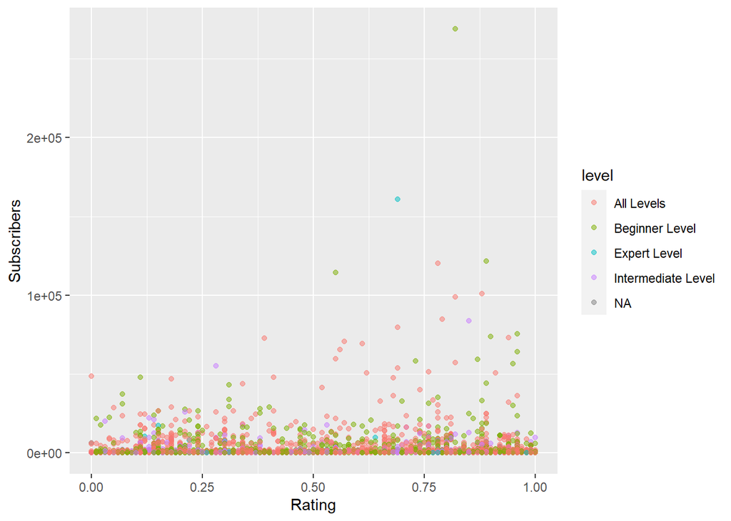

```r
ggplot(data= udemy_courses, aes(x= Rating , y = num_subscribers ))+
  geom_point(alpha = 0.5, aes(color = level))+
  labs(y= "Subscribers")
```

## **Price Versus Rating**

Do highly priced courses receive higher ratings? It is often presumed that expensive courses are of great quality thus attracting an upward rating.

Evidently, there is no clear relationship between the price of the courses and their ratings. Surprisingly, many free courses have very high ratings.

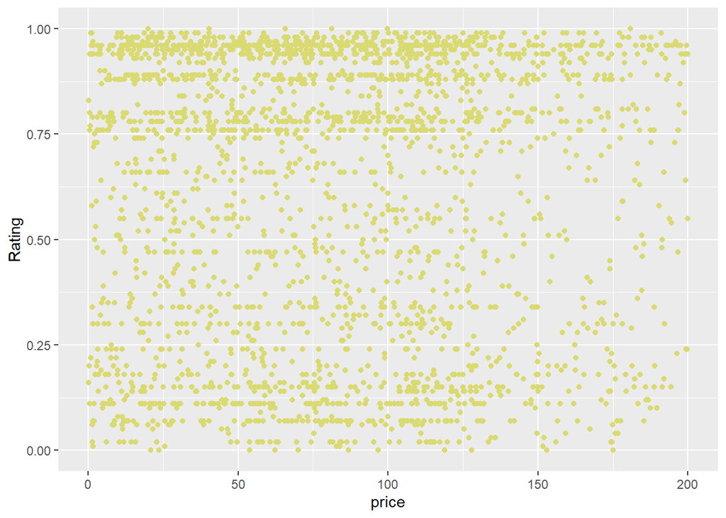

```r
ggplot(data= udemy_courses, aes(x= price, y = Rating))+
 geom_point(position = position_jitter(w=100, h=0), color= "#dada72")+
   scale_x_continuous(limits = c(0,200))
```

## **Data Cleaning**

We discovered missing values in our dataset, let’s remove them. Additionally, we do not need the url column, so we got to drop it off. We should also ensure that the columns are consistent, and clean_names from janitor package will be handy. Furthermore, we will remove the strings ‘level’ and ‘levels’ from the records in the level column. ‘Beginner’, ‘Intermediate’, etc., can suffice in place of ‘Beginner level’, ‘All levels,’ etc. str_replace_all function from the stringr package will be useful here.

```r
udemy_courses <- udemy_courses[!is.na(udemy_courses$course_id),] #only return the rows where course_id is not null.
sum(is.na(udemy_courses))
```

```
## [1] 0
```

```r
udemy_courses<- udemy_courses %>%
  select(-url)# return all columns except "url"

udemy_courses<- clean_names(udemy_courses) # For consistent casing and naming of the columns

udemy_courses$level <- str_replace_all(udemy_courses$level, " Level", "")
udemy_courses$level <- str_replace_all(udemy_courses$level, " Levels", "")
udemy_courses$level <- ifelse(udemy_courses$level== "Alls", "All",udemy_courses$level)
```

## **Feature Engineering**

There is need for the creation of some new features like, ‘year’ and hour. This will help in knowing the years and the hours the courses were posted.

```r
udemy_courses$year <- year(udemy_courses$published_timestamp) # creating the 'year' column

udemy_courses$posting_hour <- hour(udemy_courses$published_timestamp) # creating the 'hour' column
udemy_courses$free_paid <- ifelse(udemy_courses$price == 0, "Free", "Paid") # creating 'free_paid' column
```

### **Analysis**

Our data has been explored and some cleaning done. Let us now conduct some analysis.

## **Number of Courses Per Level**

We can see that the courses of all levels take the lead. Expert level courses are the least published during the period.

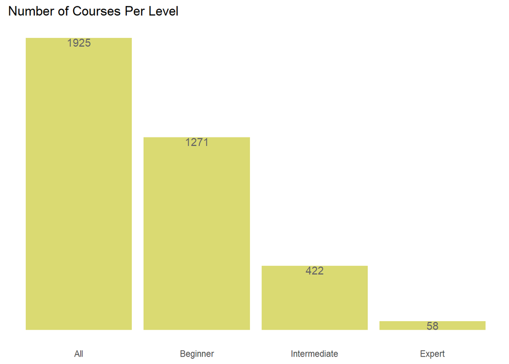

```r
level_courses <- udemy_courses%>%
  group_by(level) %>%
  summarise(number_of_courses = n()) %>%
  arrange(desc(number_of_courses))

ggplot(level_courses, aes(x= reorder(level,-number_of_courses), y = number_of_courses))+
  geom_col(fill = "#dada72")+
   geom_text(aes(label = number_of_courses), color= "#666666", vjust = 1)+
  theme_classic()+
   theme(axis.title.y = element_blank(),
        axis.text.y = element_blank(),
        axis.line = element_blank(),
        axis.ticks = element_blank(),
        axis.title.x = element_blank()
   )+
  labs(title = "Number of Courses Per Level")
```

## **Number of Subscribers Per Level**

Expert level subscribers are very few. All level subscribers still take the lead.

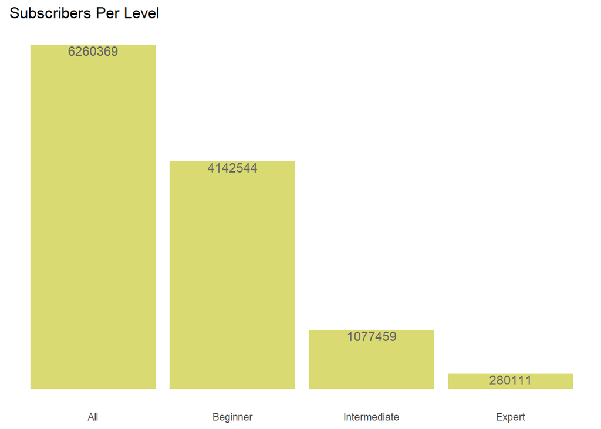

```r
level_subscribers<- udemy_courses %>%
  group_by(level) %>%            # Creating a subset of the level subscribers
  summarise(subscribers = sum(num_subscribers)) %>%
arrange(desc(subscribers))

ggplot(level_subscribers, aes(x= reorder(level, -subscribers), y = subscribers ))+
  geom_col(fill= "#dada72" )+
  geom_text(aes(label = subscribers),color= "#666666", vjust = 1.1)+
  theme_classic()+
  theme(axis.text.y = element_blank(),
        axis.title.y = element_blank(),
        axis.title = element_blank(),
        axis.ticks = element_blank(),
        axis.line = element_blank()
        )+
  labs(title = "Subscribers Per Level")
```

```r
subject_subscribers <- udemy_courses %>%
  group_by(subject, level) %>%
  summarise(subscribers = n()) %>%
  arrange(subject, -subscribers)
print(subject_subscribers)
```

```
## # A tibble: 16 × 3
## # Groups:   subject [4]
##    subject             level        subscribers
##    <chr>               <chr>              <int>
##  1 Business Finance    All                  633
##  2 Business Finance    Beginner             399
##  3 Business Finance    Intermediate         134
##  4 Business Finance    Expert                25
##  5 Graphic Design      All                  335
##  6 Graphic Design      Beginner             184
##  7 Graphic Design      Intermediate          76
##  8 Graphic Design      Expert                 7
##  9 Musical Instruments All                  324
## 10 Musical Instruments Beginner             266
## 11 Musical Instruments Intermediate          78
## 12 Musical Instruments Expert                12
## 13 Web Development     All                  633
## 14 Web Development     Beginner             422
## 15 Web Development     Intermediate         134
## 16 Web Development     Expert                14
```

## **Revenue Per Level**

What are the most priced course levels ? Which ones are charged cheaply? As expected, All level courses generated high revenue for udemy, while expert level courses generating the least amount of revenue.

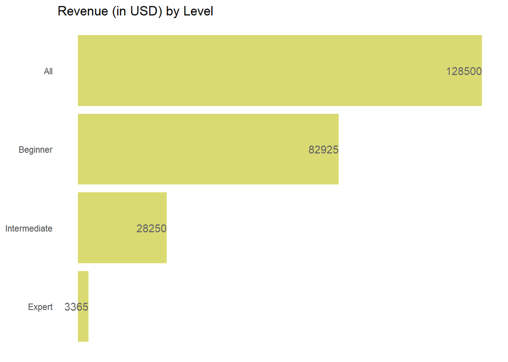

```r
level_revenue <- udemy_courses %>%
  group_by(level) %>%
  summarise(revenue = sum(price)) %>%
  arrange(-revenue)


ggplot(level_revenue, aes(x= reorder(level,revenue), y= revenue))+geom_col(fill ="#dada72" )+
  geom_text(aes(label= revenue) ,color= "#666666", hjust = 1)+
  labs(title = "Revenue (in USD) by Level")+
    theme_classic()+
  theme(axis.title = element_blank(),
        axis.text.x  = element_blank(),
        axis.line = element_blank(),
        axis.ticks = element_blank())+
  coord_flip()
```

## **The Revenue Trend Across Years**

There has been a steady increase in course revenues for udemy since 2011 to 2016. However, there was a sharp decline in revenue in 2016 through to 2017.

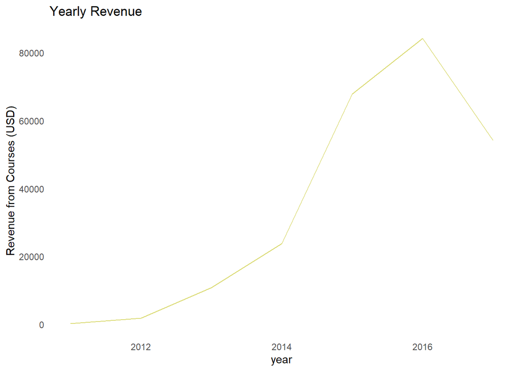

```r
year_revenue <- udemy_courses %>%
  group_by(year) %>%
  summarise(revenue = sum(price))

ggplot(year_revenue, aes(x=year, y= revenue))+
  geom_line(color = "#dada72")+
  theme_classic()+
  theme(axis.line = element_blank(),
        axis.ticks = element_blank()
        )+
labs(title = "Yearly Revenue", y= "Revenue from Courses (USD)")
```

## **Top 20 Courses in Terms of Content Duration**

“The Complete figure Drawing Course HD” is the longest course in terms of content duration. The course is 78.5 hours long.

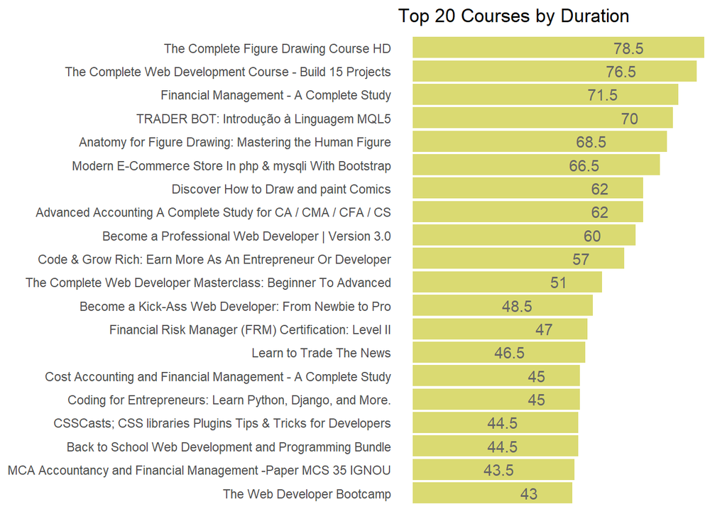

```r
top_20 <- udemy_courses %>%
  select(course_title, content_duration) %>%
  top_n(20, wt= content_duration) %>%
  arrange(-content_duration)

ggplot(top_20, aes(x= reorder(course_title, content_duration), y = content_duration))+
  geom_col(fill = "#dada72" )+
  theme_classic()+
  theme(axis.title.y = element_blank(),
        axis.line = element_blank(),
        axis.ticks = element_blank(),
        axis.title.x = element_blank(),
        axis.text.x = element_blank())+
   geom_text(aes(x = course_title, y = content_duration,
                 label = content_duration),color= "#666666", hjust = 3)+
  labs(title = "Top 20 Courses by Duration")+
  coord_flip()
```

### **The Preferred Posting Hours**

For the period, the content creators posted their courses between 3PM and midnight, with most courses uploaded at 6 PM. This makes sense because most content creators are also full time employees, and they only find time for udemy project during off-work hours.

```r
udemy_courses %>%
  group_by(posting_hour) %>%
  summarise(number_of_times = n()) %>%
  arrange(-number_of_times)
```

```
## # A tibble: 24 × 2
##    posting_hour number_of_times
##           <int>           <int>
##  1           18             397
##  2           17             377
##  3           21             360
##  4           22             320
##  5           16             291
##  6           20             278
##  7           19             255
##  8           23             227
##  9            0             219
## 10           15             187
## # … with 14 more rows
```

## **Free Courses and Paid Courses**

Generally, there are many paid courses compared to free courses.

```r
udemy_courses %>%
  group_by(free_paid) %>%
  summarise(number_of_courses = n())
```

```
## # A tibble: 2 × 2
##   free_paid number_of_courses
##   <chr>                 <int>
## 1 Free                    311
## 2 Paid                   3365
```

```r
free.paid <- udemy_courses %>%
  group_by(level, free_paid) %>%
  summarise(number_of_courses = n()) %>%
  arrange(-number_of_courses)
print(free.paid)
```

```
## # A tibble: 8 × 3
## # Groups:   level [4]
##   level        free_paid number_of_courses
##   <chr>        <chr>                 <int>
## 1 All          Paid                   1756
## 2 Beginner     Paid                   1171
## 3 Intermediate Paid                    387
## 4 All          Free                    169
## 5 Beginner     Free                    100
## 6 Expert       Paid                     51
## 7 Intermediate Free                     35
## 8 Expert       Free                      7
```